# Technical Resource Allocation in Unity: Optimizing Frame Rates and Player Experience

### Details of variables used

| Name | Variable | Type | Value |
| --- | --- | --- | --- |
| Levels | `LEVEL` | Continuous (Integer) | $[1,27]$ |
| Actual Audio | `AA` | Categorical (Ordinal) | $[1,3]$ |
| Actual Graphics | `AG` | Categorical (Ordinal) | $[1,3]$ |
| Actual Physics | `AP` | Categorical (Ordinal) | $[1,3]$ |
| Audio Rating | `AR` | Categorical (Ordinal) | $[1,5]$ |
| Graphics Rating | `GR` | Categorical (Ordinal) | $[1,5]$ |
| Physics Rating | `PR` | Categorical (Ordinal) | $[1,5]$ |
| Enjoyment Rating | `ER` | Categorical (Ordinal) | $[1,5]$ |
| Comfort Rating | `CR` | Categorical (Ordinal) | $[1,5]$ |
| Overall Satisfaction Rating | `OR` | Continuous (Integer) | $[1,5]$ |
| Score | `SCORE` | Continuous (Integer) | $[0,1000]$ |
| Average FPS | `AVGFPS` | Continuous (Integer) | $[30,60]$ |
| Gaming Interest and Experience Rating | `GAMING` | Categorical (Ordinal) | $[1,5]$ |
| Participant Number | `PCP` | Continuous (Integer) | $[1,24]$ |
| Player Experience (weighted sum of all `_R`) | `PE` | Continuous (Decimal) | $[1,5]$ |
| Normalized data of `AA, AG, AP, AVGFPS, PE` | `NAA`, `NAG`, `NAP`, `NAVGFPS`, `NPE` | Continuous (Decimal) | $[0,1]$ |
| Normalized data of $0.5AVGFPS+0.5PE$ | `NAVGFPSPE` | Continuous (Decimal) | $[0,1]$ |

### Primary Research Questions

1. Which of the technical variables (`AA`/`AG`/`AP`) have the most influence on AVGFPS?
2. Which of the technical variables (`AA`/`AG`/`AP`) have the most influence on PE?
3. What is the optimal combination of the technical variables (`AA`/`AG`/`AP`) to achieve optimal `NAVGFPSPE`?

### Secondary Research Questions

4. Which technical variables (`AA`/`AG`/`AP`) settings do most participants prefer?
5. Does Score (`SCORE`) depend on Comfort (`CR`)?
6. Does Gaming Interest and Experience Rating (`GAMING`) truly reflect on the variability in all the rating variables (`AR`, `GR`, `PR`, `ER`, `CR`, `OR`)?

#### Notes:

- none

## **Findings**

In order to address the research questions, I developed models tailored to each question. Provided below are the evaluation of these models along with the model descriptions.

#### **Q1. Which of the technical variables (`AA`/`AG`/`AP`) have the most influence on `AVGFPS`?**

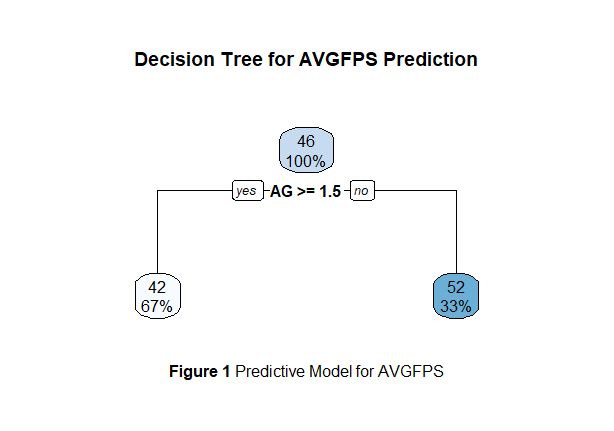

| Method | Value |
| --- | --- |
| RMSE | $2.769354$ |
| R-squared | $0.758044$ |
| Cross-validated RMSE | $1.777068, 1.763340, 2.257344$ |

**Table 1** Model Assessment

Before proceeding with utilizing the model to address the research question, I conducted a thorough assessment of its performance using three distinct methods, outlined below:

*Root Mean Squared Error*: RMSE measures the average magnitude of the errors between predicted and actual values. In this case, the RMSE is $2.769354$, indicating that, on average, the model’s predictions deviate from the actual values by approximately $2.77$ units.

*R-squared*: R-squared quantifies the proportion of the variance in the target variable that is explained by the model. A value of $0.758044$ indicates that approximately $75.8%$ of the variance in the target variable is explained by the model, suggesting a reasonably good fit.

*Cross-validated RMSE*: Cross-validation is a technique used to assess the model’s performance on unseen data by splitting the dataset into multiple subsets. The reported cross-validated RMSE values are $1.777068$, $1.763340$, and $2.257344$, which represent the RMSE calculated on different subsets of the data. This provides insights into the model’s stability and generalization performance across different data partitions.

In short, the model demonstrates moderate predictive performance, underscored by the R-squared value. Furthermore, the consistency observed in the cross-validated RMSE values across different data subsets enhances confidence in the model’s generalization capability.

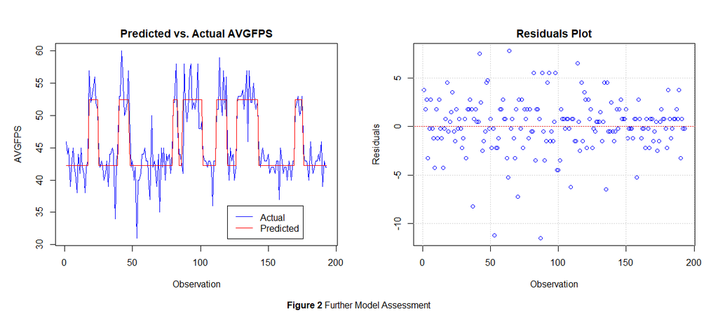

To further validate the robustness of the model, a visual examination of the Predicted vs Actual AVGFPS Plot was conducted. This plot shows the model’s predicted average frames per second (AVGFPS) values against the actual AVGFPS values from the dataset. Its capacity to accurately predict AVGFPS values, as demonstrated by the close alignment between predicted and actual values, instills confidence in its reliability and robustness.

The Residual Plot analysis reinforces the notion that the model is a good fit for the dataset. The random distribution of residuals, with the majority clustering around y = 0, underscores the model’s accuracy in predicting AVGFPS values. While a few outliers exist, their limited presence does not detract significantly from the model’s overall performance. As such, the Residual Plot provides further evidence of the model’s suitability for addressing the research question with confidence.

| Variable | Importance (VarImp) | Approx % |
| --- | --- | --- |
| `AG` | $0.6931757927$ | $99.74$ |
| `AP` | $0.0012707157$ | $0.18$ |
| `AA` | $0.0005060404$ | $0.07$ |

**Table 2** Outcome

Graphics (`AG`): With a VarImp value of $0.6931757927$, Graphics emerges as the dominant factor among the three feature variables in predicting FPS. Notably, Graphics exhibits overwhelming importance, constituting approximately $99.74$% of the total importance across all features. This VarImp value close to 1 underscores the significant impact that changes in the Graphics feature have on FPS predictions. Therefore, Graphics is unequivocally identified as the most influential variable in Model 1 for predicting FPS.

Physics (`AP`): Conversely, Physics yields a VarImp value of $0.0012707157$, representing a mere $0.18$% of the total feature importance. This substantially lower VarImp value indicates that Physics exerts minimal influence on FPS predictions compared to Graphics. Changes in the Physics feature have negligible impact on FPS predictions in comparison to Graphics.

Audio (`AA`): Similarly, the VarImp value for Audio is $0.0005060404$, corresponding to a mere $0.07$% of the total feature importance. This minimal VarImp value suggests that Audio holds even less sway over FPS predictions compared to both Graphics and Physics. In essence, changes in the Audio feature have the least discernible impact on FPS predictions among the three variables.

In summary, Graphics (`AG`) emerges as the overwhelmingly dominant variable in determining `AVGFPS`, commanding a staggering $99.74$% of the total feature importance. Physics (`AP`) follows with a modest $0.18$%, while Audio (`AA`) trails behind with a mere $0.07$%. These findings unequivocally highlight the paramount importance of Graphics in predicting FPS, positioning it as the primary focus for optimizing performance in Model 1.

#### **Q2. Which of the technical variables (`AA`/`AG`/`AP`) have the most influence on `PE`?**

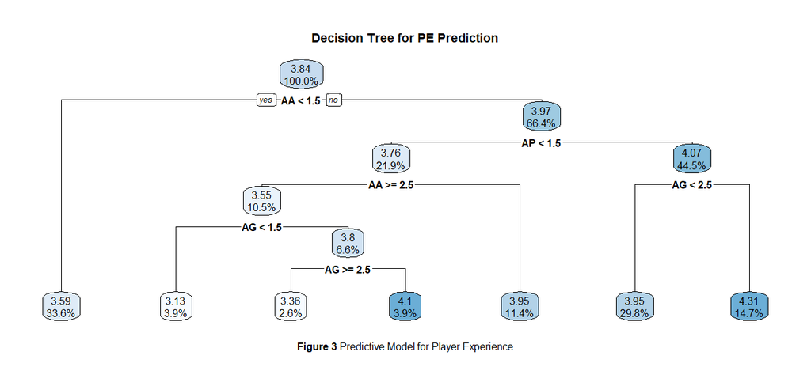

| Method | Value |
| --- | --- |
| RMSE | $0.9346277$ |
| R-squared | $-0.06896572$ |
| Cross-validated RMSE | $0.9475976, 0.9475561, 0.9492149$ |

**Table 3** Model Assessment

*Root Mean Squared Error*: The RMSE for this model is $0.9346277$. Here, the RMSE suggests that, on average, the model’s predictions deviate from the actual values by approximately $0.93$ units.

*R-squared*: The model’s R-squared value is $-0.06896572$. In this instance, the negative R-squared value indicates that the model performs worse than a horizontal line fitting the data.

*Cross-validated RMSE*: The reported cross-validated RMSE values are $0.9475976$, $0.9475561$, and $0.9492149$, indicating consistent performance across different subsets of the data.

Given the limitation of our study focusing solely on decision tree modeling techniques, it’s important to acknowledge the implications for predictive performance. With the model assessment revealing a poor predictive capability, characterized by a negative R-squared value and a relatively high RMSE, it’s evident that this model may not be optimal for prediction tasks in this case. However, despite these limitations, our study will proceed with caution as it still provides valuable insights into the relationships between variables.

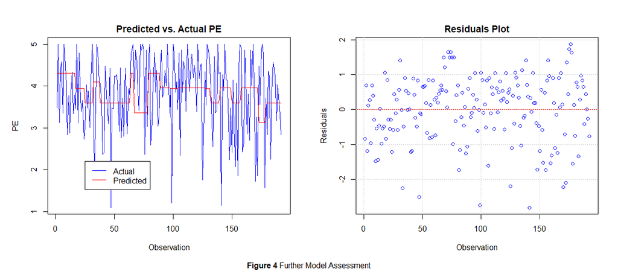

To further assess the robustness of Model 2, a visual examination of the Predicted vs Actual PE Plot was conducted. Unlike the Predicted vs Actual AVGFPS plot, the correlation between predicted and actual values in the PE plot is not as high. This discrepancy can be attributed to the unpredictable nature of human behavior, leading to larger deviations between predicted and actual values for PE compared to AVGFPS. However, there is still some alignment between the predicted and actual values, although not as closely as observed in the first model.

The Residual Plot analysis for Model 2 indicates a less favorable scenario compared to Model 1. While the residuals are still randomly distributed, there are fewer clusters around y=0, indicating a less accurate prediction of PE values. Additionally, there are fewer outliers compared to Model 1, suggesting a more consistent performance, albeit with less accuracy.

In conclusion, Model 2 may not be the best predictive model in this case, primarily due to the unpredictable nature of human behavior affecting PE values. However, given the limitations of the paper and the alignment between the two models’ plots to some extent, we will proceed with caution in utilizing Model 2 for identifying the most influential variable.

| Variable | Importance (VarImp) | Approx % |
| --- | --- | --- |
| `AG` | $0.38158180$ | $72.47$ |
| `AA` | $0.08638892$ | $16.41$ |
| `AP` | $0.05859870$ | $11.13$ |

**Table 4** Outcome

Graphics (`AG`): With a VarImp value of $0.38158180$, Graphics emerges as the most influential factor among the three feature variables in predicting `PE`. Notably, Graphics accounts for approximately $72.47$% of the total importance across all features. This substantial importance underscores the significant impact that changes in the Graphics feature have on `PE` predictions.

Audio (`AA`): Following Graphics, Audio exhibits a VarImp value of $0.08638892$, representing approximately $16.41$% of the total feature importance. This notable contribution suggests that Audio plays a significant role in predicting PE, although to a lesser extent compared to Graphics. Changes in the Audio feature significantly affect PE predictions, albeit not as prominently as Graphics.

Physics (`AP`): Lastly, Physics yields a VarImp value of $0.05859870$, constituting approximately $11.13$% of the total feature importance. While Physics contributes less to PE predictions compared to Graphics and Audio, its importance is still noteworthy. Changes in the Physics feature moderately impact PE predictions, albeit to a lesser degree than both Graphics and Audio.

#### **Q3. What is the optimal combination of the technical variables (`AA`/`AG`/`AP`) to achieve optimal `NAVGFPSPE`?**

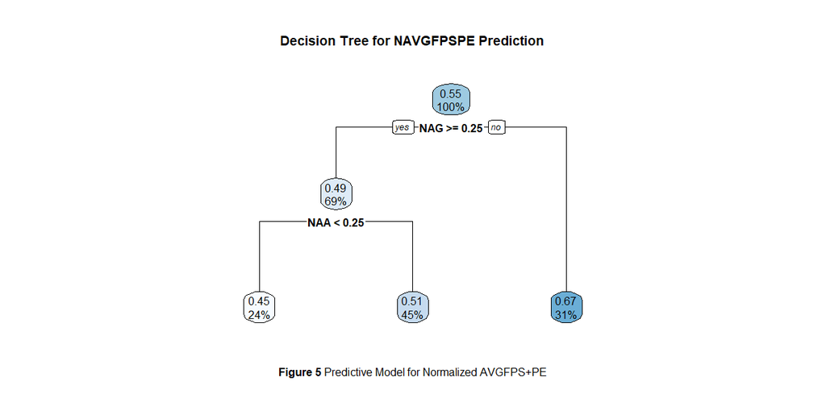

| Method | Value |
| --- | --- |
| RMSE | $0.1761723$ |
| R-squared | $0.2455282$ |
| Cross-validated RMSE | $0.4121428, 0.4135205, 0.4293897$ |

**Table 5** Model Assessment

*Root Mean Squared Error*: The RMSE for our model is $0.1761723$, suggesting that, on average, the model’s predictions deviate from the actual values by approximately $0.176$ units.

*R-squared*: The model’s R-squared value is $0.2455282$, indicating that approximately $24.55$% of the variance in the target variable is explained by the model, suggesting a moderate fit.

*Cross-validated RMSE*: The reported cross-validated RMSE values are $0.4121428$, $0.4135205$, and $0.4293897$, showing consistent performance across different subsets of the data.

In summary, the model demonstrates moderate predictive performance, as indicated by the R-squared value. Furthermore, the consistency observed in the cross-validated RMSE values across different data subsets enhances confidence in the model’s generalization capability.

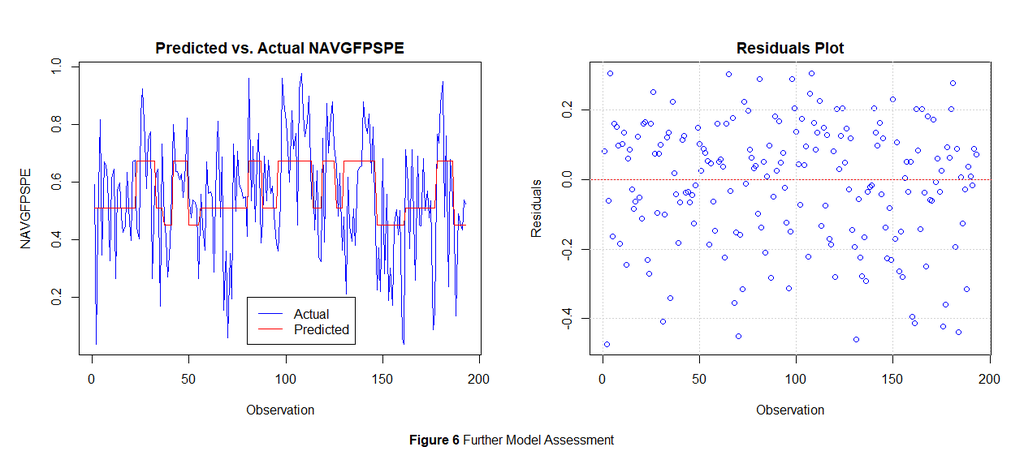

To further assess the robustness of Model 3, a visual examination of the Predicted vs Actual NAVGFPSPE Plot was conducted. Similar to Model 2, the correlation between predicted and actual values in the NAVGFPSPE plot is not significantly high. This can be attributed to the complex nature of predicting NAVGFPSPE, which involves multiple factors such as normalized audio (`NAA`), normalized graphics (`NAG`), and normalized physics (`NAP`). Despite this, there is still some alignment between the predicted and actual values, indicating a reasonable fit for the model.

The Residual Plot analysis for Model 3 shows little difference compared to Model 2. While the residuals are still randomly distributed, there are fewer clusters around y=0 compared to Model 1. However, similar to Model 2, there are fewer outliers, suggesting a more consistent performance. Although Model 3 may not be the best predictive model, it demonstrates moderate predictive capability for NAVGFPSPE.

| Variable | Importance (VarImp) | Approx % |
| --- | --- | --- |
| `NAG` | $0.204909381$ | $80.22$ |
| `NAA` | $0.042800870$ | $16.76$ |
| `NAP` | $0.007733559$ | $3.03$ |

**Table 6** Outcome

Normalized Audio (`NAA`): Following Normalized Graphics, Normalized Audio exhibits a VarImp value of $0.042800870$, representing approximately $16.76$% of the total feature importance. This notable contribution suggests that Normalized Audio plays a significant role in predicting Normalized AVGFPS+PE, although to a lesser extent compared to Normalized Graphics. Changes in the Normalized Audio feature significantly affect the combined outcome, albeit not as prominently as Normalized Graphics.

Normalized Physics (`NAP`): Lastly, Normalized Physics yields a VarImp value of $0.007733559$, constituting approximately $3.03$% of the total feature importance. While Normalized Physics contributes less to Normalized AVGFPS+PE predictions compared to Normalized Graphics and Normalized Audio, its importance is still noteworthy. Changes in the Normalized Physics feature moderately impact the combined outcome, albeit to a lesser degree than both Normalized Graphics and Normalized Audio.

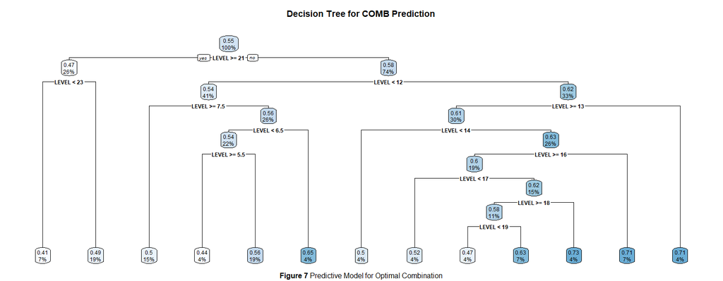

[output not shown]

**Table 7** Findings of Optimal Combination Analysis

These findings suggest that the most optimal combination (`COMB`) is 5, where `AA` is 2, `AG` is 1, and `AP` is 2. This is followed by `COMB` 4, where `AA` is 2, `AG` is 1, and `AP` is 1, and `COMB` 6, where `AA` is 2, `AG` is 1, and `AP` is 3. These results further highlight the importance of `AG` in the model, reinforcing its significant influence on optimizing performance.

This additional analysis provides valuable insights into the relationship between technical variables and player experience, aiding in the optimization of resource allocation in Unity for enhanced player satisfaction and gaming performance.

### **Primary Research Question Summary**

**Q1. Which of the technical variables (`AA`/`AG`/`AP`) have the most influence on AVGFPS?**

A1. Graphics (`AG`) emerges as the overwhelmingly dominant variable in determining `AVGFPS`, commanding a staggering $99.74$% of the total feature importance. Physics (`AP`) follows with a modest $0.18$%, while Audio (`AA`) trails behind with a mere $0.07$%.

**Q2. Which of the technical variables (`AA`/`AG`/`AP`) have the most influence on PE?**

A2. Graphics (`AG`) emerges as the most influential variable in determining PE, commanding a substantial $72.47$% of the total feature importance. Audio (`AA`) follows with a notable $16.41$%, while Physics (`AP`) trails behind with $11.13$%.

**Q3. What is the optimal combination of the technical variables (`AA`/`AG`/`AP`) to achieve optimal `NAVGFPSPE`?**

A3. The most optimal combination (`COMB`) is 5, where `AA` is 2, `AG` is 1, and `AP` is 2. This is followed by `COMB` 4, where `AA` is 2, `AG` is 1, and `AP` is 1, and `COMB` 6, where `AA` is 2, `AG` is 1, and `AP` is 3.